# Exercise_chap_04.R

2022-09-28

Some Exercises from chapter o4

```r
rm(list=ls())
suppressPackageStartupMessages(library(mosaic))
```

browseURL(“http://www.principlesofeconometrics.com/poe5/data/def/newbroiler.def”)

```r
load(url("http://www.principlesofeconometrics.com/poe5/data/rdata/newbroiler.rdata"))
head(newbroiler)
```

```
##   year    q    y       p      pb   pcorn pf    qprod     lexpts popgro
## 1 1950 14.3 7863 2.88382 1.29461 2.48133 NA 1826.616 -0.1718388     NA
## 2 1951 15.1 7953 2.80385 1.40385 2.77308 NA 1975.677 -0.1648426 1.7161
## 3 1952 15.3 8071 2.75849 1.36604 2.69057 NA 1981.376 -0.1922588 1.7286
## 4 1953 15.2 8319 2.67041 1.06742 2.34831 NA 2052.745 -0.1668136 1.6635
## 5 1954 15.8 8276 2.39405 1.01859 2.35688 NA 2154.065 -0.1749048 1.7711
## 6 1955 14.7 8675 2.50000 1.01119 2.09328 NA 2055.664 -0.1671042 1.7760
```

Units of the variables:

p - price (no unit), just price index

q - per capita consumption (pound) Model 1: lin-lin model

```r
m1 <-  lm(q ~ p, data = newbroiler)

coef(m1)
```

```
## (Intercept)           p
##    57.95564   -18.40283
```

```r
coef(m1)[2]
```

```
##         p
## -18.40283
```

more general output

```r
summary(m1)
```

```
##
## Call:
## lm(formula = q ~ p, data = newbroiler)
##
## Residuals:
##    Min     1Q Median     3Q    Max
## -8.182 -5.563 -2.941  5.981 13.402
##
## Coefficients:
##             Estimate Std. Error t value Pr(>|t|)
## (Intercept)   57.956      2.575   22.50  < 2e-16 ***
## p            -18.403      1.661  -11.08 4.58e-15 ***
## ---
## Signif. codes:  0 '***' 0.001 '**' 0.01 '*' 0.05 '.' 0.1 ' ' 1
##
## Residual standard error: 6.513 on 50 degrees of freedom
## Multiple R-squared:  0.7105, Adjusted R-squared:  0.7047
## F-statistic: 122.7 on 1 and 50 DF,  p-value: 4.584e-15
```

Interprate the parameters:

Intercept:

57.956: The expected level of per capita consumption when price is zero.

Slope:

-18.403: A 1 unit increase in price leads to (approximately ) 18.40 pound decrease in the level of expected/average/ per capita consumption q. Interprate R^2:

71.05% of variation in per capita consumption is explained by the variation in price. : the remaining 29% is the unexplained part

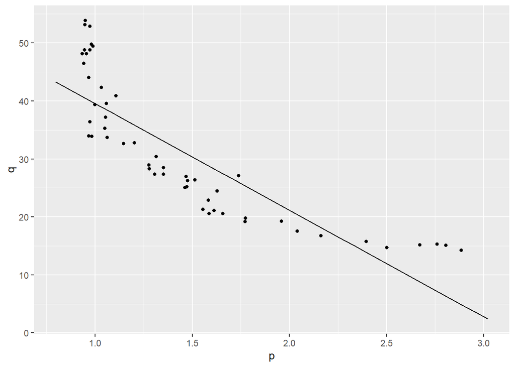

```r
plotModel(m1)
```

confidence interval of the parameter

```r
confint(m1)
```

```
##                 2.5 %    97.5 %
## (Intercept)  52.78315  63.12813
## p           -21.73935 -15.06631
```

Prediction: Predict the E(q|p) at a given value of p, p= 0.98

E(q|p = 0.98)

```r
f <- makeFun(m1)
f(0.98)
```

```
##        1
## 39.92087
```

```r
f(p = 0.98)
```

```
##        1
## 39.92087
```

```r
f(p = 0.98, interval = "confidence", level = 0.95)
```

```
##        fit      lwr      upr
## 1 39.92087 37.51904 42.32269
```

Model 2: lin-log

```r
m2 <- lm(q ~ log(p), data = newbroiler)
summary(m2)
```

```
##
## Call:
## lm(formula = q ~ log(p), data = newbroiler)
##
## Residuals:
##    Min     1Q Median     3Q    Max
## -8.286 -4.186 -1.747  3.818 11.006
##
## Coefficients:
##             Estimate Std. Error t value Pr(>|t|)
## (Intercept)  41.2111     0.9898   41.63   <2e-16 ***
## log(p)      -31.9078     2.1584  -14.78   <2e-16 ***
## ---
## Signif. codes:  0 '***' 0.001 '**' 0.01 '*' 0.05 '.' 0.1 ' ' 1
##
## Residual standard error: 5.223 on 50 degrees of freedom
## Multiple R-squared:  0.8138, Adjusted R-squared:  0.8101
## F-statistic: 218.5 on 1 and 50 DF,  p-value: < 2.2e-16
```

Interprate the parameters:

```r
coef(m2)[2]/100
```

```
##    log(p)
## -0.319078
```

-0.319078 : a 1% increase in price, leads to (approximately) 0.319 pound decrease in the level of per capita consumption q

Interprate R^2:

```
81.38% of variation in per capita consumption is explained by the variation in log price.
```

confidence interval of the parameter

```r
confint(m2)
```

```
##                 2.5 %    97.5 %
## (Intercept)  39.22304  43.19923
## log(p)      -36.24300 -27.57260
```

Prediction: Predict the E(q|p) at a given value of p, p= 0.98

```r
coef(m2)[1]-(coef(m2)[2]*log(0.98))
```

```
## (Intercept)
##    40.56651
```

more simply

```r
f <- makeFun(m2)
f(0.98)
```

```
##        1
## 41.85576
```

```r
f(p = 0.98)
```

```
##        1
## 41.85576
```

```r
f(p = 0.98, interval = "confidence", level = 0.95)
```

```
##        fit      lwr      upr
## 1 41.85576 39.80697 43.90455
```

Model 3: log- linear model

```r
m3 <- lm(log(q) ~ p, data = newbroiler)
summary(m3)
```

```
##
## Call:
## lm(formula = log(q) ~ p, data = newbroiler)
##
## Residuals:
##      Min       1Q   Median       3Q      Max
## -0.25251 -0.12407 -0.05208  0.14091  0.28644
##
## Coefficients:
##             Estimate Std. Error t value Pr(>|t|)
## (Intercept)  4.33079    0.06323   68.50   <2e-16 ***
## p           -0.66422    0.04078  -16.29   <2e-16 ***
## ---
## Signif. codes:  0 '***' 0.001 '**' 0.01 '*' 0.05 '.' 0.1 ' ' 1
##
## Residual standard error: 0.1599 on 50 degrees of freedom
## Multiple R-squared:  0.8414, Adjusted R-squared:  0.8382
## F-statistic: 265.2 on 1 and 50 DF,  p-value: < 2.2e-16
```

Interpretation the parameters:

```r
100*coef(m3)[2]
```

```
##         p
## -66.42237
```

a 1 unit increase in price leads to (approximately) a 66.4 % decrease in q. Prediction in the log -linear model:

E(q|p = 0.98) Manually

```r
coef(m3)[1]+coef(m3)[2]*0.98
```

```
## (Intercept)
##    3.679846
```

```r
exp(coef(m3)[1]+coef(m3)[2]*0.98)
```

```
## (Intercept)
##    39.64029
```

```r
yn <- function(x){exp(coef(m3)[1]+coef(m3)[2]*x)}  # not corrected
yn(0.98) # not corrected
```

```
## (Intercept)
##    39.64029
```

Alternatively

```r
y <- makeFun(m3)
y(0.98)  # predict q for the uncorrected depe.var.
```

```
##        1
## 39.64029
```

However, there is one problem here. what is that? Since the dep. var. is in log form, we have log transformed error /residual terms. That means e = log(q) - b1 -p We have to adjust that. How? Look at your book on page (175 -178

```r
s2 <- deviance(m3)/m3$df.residual   # The variance in the model, sigma squared

yc <- function(x){exp(coef(m3)[1]+coef(m3)[2]*x+s2/2)}  # corrected
yc(0.98)  # corrected
```

```
## (Intercept)
##    40.15032
```

Alternatively, using the mosaic::makeFun()

```r
y(0.98)*exp(s2/2) # must adjust
```

```
##        1
## 40.15032
```

Remember: the mosaic::makeFun() function predict the dependent variable in levels but w/o se correction

```r
           # we have to adjsut
```

we have estimated three different models. Now let us compare the three models in terms of R^2 values, i.e., which model has the highest R^2 value. The best model is the one with the highest R^2 value.  
R^2 from model 1

```r
summary(m1)$r.squared
```

```
## [1] 0.7105309
```

R^2 from model 2

```r
summary(m2)$r.squared
```

```
## [1] 0.8138129
```

R^2 from model 3

```r
summary(m3)$r.squared
```

```
## [1] 0.8413902
```

But this is explained variation in the log dep. variable. That means we have the explained variation in log form of the dep.variable Change to explained variation in dep. variable in levels. How? A generalized R^2 measure (page 176): comparing two models, y = and log(y)=

```r
cor(newbroiler$q, yc(newbroiler$p))
```

```
## [1] 0.9047122
```

```r
cor(newbroiler$q, yc(newbroiler$p))^2
```

```
## [1] 0.8185042
```

Alternatively

```r
cor(newbroiler$q, y(newbroiler$p)*exp(s2/2))^2
```

```
## [1] 0.8185042
```